# Aula 11 - Econometria de Séries Temporais

Autor

João Ricardo F. de Lima

Data de Publicação

9 de junho de 2025

# VEC - Vetorial Autorregressivo com correção de erro

Um dos pressupostos para se estimar um modelo VAR é que as variáveis sejam estacionárias. Isso significa que se essa hipótese for violada, é necessário realizar outro tipo de análise, verificando a existência de **cointegração** entre duas ou mais variáveis, isto é, se existe uma relação de longo-prazo entre elas.

Se as séries não forem estacionárias, as mesmas podem estar relacionadas ao longo do tempo. Se for esse o caso, diz-se que as séries possuem uma tendência comum, o que nos permite avaliar a relação entre elas.

Sejam $Y_t$, $X_t$ e $Z_t$ três séries temporais e a seguinte relação de interesse:

$$Y_t=\alpha+\beta X_t+ \gamma Z_t + \epsilon_t$$

Neste caso tem que se considerar as seguintes possibilidades:

1. Se $Y_t$, $X_t$ e $Z_t$ são estacionárias, estima-se a equação acima em nível
2. Se $Y_t$, $X_t$ e $Z_t$ são não estacionárias, tem-se outras possibilidades:

Se $Y_t$, $X_t$ e $Z_t$ são não estacionárias mas co-integradas, deve-se estimar um Modelo de Correçao de Erro (MCE) na forma uni ou multivariada dado por

$$\Delta Y_t=\alpha+\beta \Delta X_t+ \gamma \Delta Z_t +\lambda \hat{\epsilon}_{t-1}+u_t$$

em que $\hat{\epsilon}_{t-1}$ são os resíduos da equação do slide anterior.

Se $Y_t$, $X_t$ e $Z_t$ são não estacionárias e não co-integradas, deve-se ajustar a equação do slide anterior em primeiras diferenças, ou seja,

$$\Delta Y_t=\alpha+\beta \Delta X_t+ \gamma \Delta Z_t + v_t$$

## Co-integração - Relações de Equilíbrio de Longo Prazo

A combinação linear é dada por

$$Z_t=a_1Y_{1t}+a_2Y_{2t}+a_3Y_{3t}+\dots+a_kY_{kt}$$

O vetor $a=[a_1 \quad a_2\quad a_3\quad \dots\quad a_k]'$ é chamado de “vetor de co-integração”. Os casos de interesse para as relações econômicas são quando a combinação linear é estacionária, ou seja, I(0).

Considere $Y_t \sim I(1)$, $X_t \sim I(1)$ e $Z_t \sim I(1)$ e a relação:

$$Y_t=\beta_0+\beta_1 X_t+ \beta_2 Z_t$$

esta relação estará em equilíbrio de longo prazo se $0=Y_t-\beta_0-\beta_1 X_t- \beta_2 Z_t$, sendo que para o equilíbrio existir e ter significado econômico, o resíduo deve ser estacionário.

Assim, com $Y_t \sim I(1)$, $X_t \sim I(1)$ e $Z_t \sim I(1)$ e $\epsilon_t=Y_t-\beta_0-\beta_1 X_t- \beta_2 Z_t \sim I(0)$, tem-se que as três séries são co-integradas com vetor de cointegração dado por

$$\beta=[1 \quad -\beta_0\quad -\beta_1\quad -\beta_2]'$$

## Vetores de Co-integração

Os vetores de co-integração (CI) não são únicos. Podem existir várias combinações lineares estacionárias devido a existência de vários vetores de CI. O número de vetores de CI depende do número de variáveis envolvidas. Tem-se:

1. Caso de 2 variáveis: com 2 variáveis existe somente uma combinação estacionária entre as variáveis que representa uma relação de equilíbrio de longo prazo;
2. Caso de k variáveis: com k variáveis existem até k-1 vetores de co-integração linearmente independentes.

## Rank de Co-integração

O rank de CI (r) é o número de vetores de CI linearmente independentes. Para k variáveis de mesma ordem de integração e co-integradas, $1 \le r \le k-1$.

## Testes de Co-Integração - Caso Multivariado

Para se testar co-integração no caso Multivariado, suponha K variáveis todas integradas de mesma ordem I(1). Sendo as variáveis todas I(1), a existência de combinações lineares I(0) entre elas indica que estas variáveis são co-integradas. Estas combinações lineares governam o comportamento de equilíbrio de longo prazo. Em geral, existem $r\le K-1$ combinações lineares independentes que são as relações de CI e é necessário encontrar o valor de r;

Se r=K as variáveis são I(0). Se r=0, não existe relação de longo prazo entre as variáveis. Se $1 \le r \le k-1$, existem de 1 até k-1 vetores de co-integração e é necessário definir o valor de r.

A metodologia para se determinar o número de vetores de CI e estimar as relações de CI é baseada na estimação de um **Modelo Vetorial Autorregressivo** conhecido como modelo VAR, que foi desenvolvida por Johansen.

### Teste de Co-Integração de Johansen

Considere um VAR(2) com k variáveis, todas possuindo raiz unitária:

$$Y_t=\alpha+\theta_1Y_{t-1}+\theta_2Y_{t-2}+\epsilon_t$$

É possível subtrair $Y_{t-1}$ dos dois lados nesta equação e rearranjar os termos para obter:

$$\Delta Y_t=\alpha+(\theta_1+\theta_2-I)Y_{t-1}-\theta_2 \Delta y_{t-1}+\epsilon_t$$

com um pouco mais de álgebra é possível reescrever um VAR(p) com k variáveis como um VEC (VAR Reparametrizado) da forma

$$\Delta Y_t=\alpha+\Pi Y_{t-1}+ \sum_{i=1}^{p-1}\Gamma_i\Delta y_{t-i}+\epsilon_t$$

em que

$$\Pi=\sum_{j=1}^{p}\theta_j-I$$

e

$$\Gamma_i=- \sum_{j=i+1}^{p}\theta_j$$

$\Pi$ é a matriz dos coeficientes das relações de cointegração; $\Gamma$ é a matriz dos coeficientes da variável $Y$ diferenciada defasadas.

A diferença do VEC para o VAR é o termo de correção de erro $\Pi Y_{t-1}$. Engle e Granger (1987) mostraram que $\Pi$ tem rank r, $0 \le r <K$, em que r é o número de vetores de cointegração linearmente independentes entre os elementos do vetor $Y_t$. Assim, não se pode simplesmente estimar um VAR em $\Delta Y_t$ quando existe relações de cointegração pois se estaria omitindo $\Pi Y_{t-1}$. Se não existem relações de cointegração entre os elementos de $Y_t$, o rank de $\Pi$ é 0 e o termo $\Pi Y_{t-1}$ desaparece.

Se rank $(\Pi)=r<k$, pode-se mostrar que existem matrizes $\psi_{kxr}$ e $\beta_{kxr}$ tais que

$$\Pi_{KxK}=\psi_{kxr} \beta_{rxk}'$$

Substituindo na equação do VAR reparametrizado, obtém-se

$$\Delta Y_t=\alpha+ \psi \beta'Y_{t-1}+\sum_{i=1}^{p-1}\Gamma_i\Delta y_{t-i}+\epsilon_t$$

que é denominado de **Modelo de Correção de Erro Vetorial (VEC)**. O VEC, então, é um VAR (reparametrizado) com as restrições de co-integração entre as variáveis.

Tem-se que

1. $\beta'Y_{t-1}$= são as ``r’’ relações de cointegração que definem o equilíbrio de longo prazo ente as variáveis;
2. $\psi$=matriz de coeficientes de ajustamento de longo prazo;
3. $\Gamma_i$=matrizes de coeficientes que definem a dinâmica de curto prazo;

O procedimento de Johansen consiste em testar o número de raízes características diferentes de zero na matriz $\Pi$ que corresponde ao número de relações e vetores de cointegração entre as variáveis.

São utilizados dois testes:

1. **Teste do Traço**:

$H_0:r \le r_0$

$H_1:r_0<r \le k$

Estatística de teste:

$$\lambda_{traco}=-T \sum_{i=r_0+1}^{k} ln(1-\hat{\lambda_i})$$

2. **Teste da Raiz Característica Máxima**:

$H_0:r \le r_0$

$H_1:r=r_0+1$

Estatística de teste:

$$\lambda_{max}=-T ln(1-\hat{\lambda_{r_0+1}})$$

Os testes são realizados em sequencia até que a hipótese nula não seja rejeitada.

# Exemplo

Considere 3 processos simulados, sendo dois AR(1) e um passeio aleatório.

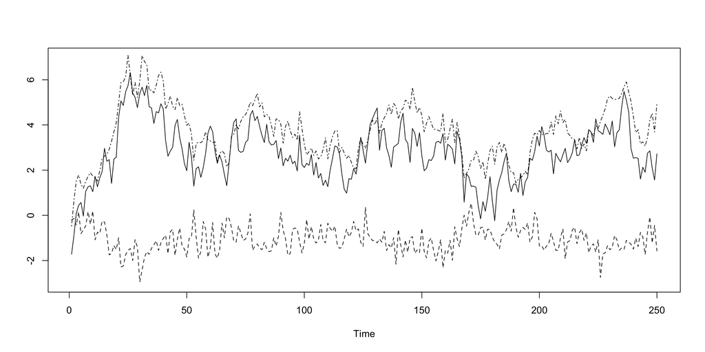

```r
set.seed(9)

e1 <- rnorm(250,0,0.5)
e2 <- rnorm(250,0,0.5)
e3 <- rnorm(250,0,0.5)

u1.ar1 <- arima.sim(model = list(ar=0.75), innov = e1, n = 250)
u2.ar1 <- arima.sim(model = list(ar=0.3), innov = e2, n = 250)

y3 <- cumsum(e3)
y1 <- 0.8*y3 + u1.ar1
y2 <- -0.3*y3 + u2.ar1


y.mat <- data.frame(y1,y2,y3)

# Figura 8.8
plot.ts(y1, lty = 1, ylim = c(-3,7), ylab = "")
lines(y2, lty = 2)
lines(y3, lty = 4)
```

A função do R ca.jo() estima as matrizes $\alpha$ e $\beta$, além das estatísticas de teste para os dois métodos.

A estimação do VEC é feita em duas etapas, na primeira se estima, por máxima verossimilhança, as relações de cointegração, e em seguida, com mínimos quadrados, os coeficientes dos termos determinísticos e de defasagem.

Nos resultados, $r=0$ equivale a hipótese de não existência de relações de cointegração, enquanto $r \leq i$ equivale à de i ou menos relações de cointegração.

Abaixo, a saída do teste do máximo autovalor:

```r
library(vars)
vecm <- ca.jo(y.mat, type = c("eigen"), ecdet = "const")

jo.results <- summary(vecm)
jo.results
```

```
######################
# Johansen-Procedure #
######################

Test type: maximal eigenvalue statistic (lambda max) , without linear trend and constant in cointegration

Eigenvalues (lambda):
[1] 3.357938e-01 1.410541e-01 4.949758e-02 1.216835e-18

Values of teststatistic and critical values of test:

           test 10pct  5pct  1pct
r <= 2 |  12.59  7.52  9.24 12.97
r <= 1 |  37.71 13.75 15.67 20.20
r = 0  | 101.47 19.77 22.00 26.81

Eigenvectors, normalised to first column:
(These are the cointegration relations)

             y1.l2       y2.l2      y3.l2   constant
y1.l2     1.000000  1.00000000  1.0000000   1.000000
y2.l2    23.739744 -0.01440361  0.9326373   0.508324
y3.l2     5.521199 -0.83720628 -6.9751085  -4.804581
constant  1.916051  0.31478225 25.5249365 -11.754289

Weights W:
(This is the loading matrix)

            y1.l2       y2.l2        y3.l2      constant
y1.d -0.002543326 -0.28362568  0.013102253 -6.443480e-18
y2.d -0.037142149 -0.01269080 -0.004450528 -9.771012e-18
y3.d -0.003204754  0.04075187  0.013609744  1.381277e-18
```

```r
vect <- ca.jo(y.mat, type = c("trace"), ecdet = "const")

jo.results <- summary(vect)
jo.results
```

```
######################
# Johansen-Procedure #
######################

Test type: trace statistic , without linear trend and constant in cointegration

Eigenvalues (lambda):
[1] 3.357938e-01 1.410541e-01 4.949758e-02 1.216835e-18

Values of teststatistic and critical values of test:

           test 10pct  5pct  1pct
r <= 2 |  12.59  7.52  9.24 12.97
r <= 1 |  50.30 17.85 19.96 24.60
r = 0  | 151.77 32.00 34.91 41.07

Eigenvectors, normalised to first column:
(These are the cointegration relations)

             y1.l2       y2.l2      y3.l2   constant
y1.l2     1.000000  1.00000000  1.0000000   1.000000
y2.l2    23.739744 -0.01440361  0.9326373   0.508324
y3.l2     5.521199 -0.83720628 -6.9751085  -4.804581
constant  1.916051  0.31478225 25.5249365 -11.754289

Weights W:
(This is the loading matrix)

            y1.l2       y2.l2        y3.l2      constant
y1.d -0.002543326 -0.28362568  0.013102253 -6.443480e-18
y2.d -0.037142149 -0.01269080 -0.004450528 -9.771012e-18
y3.d -0.003204754  0.04075187  0.013609744  1.381277e-18
```

Observe que as estatísticas de teste rejeitam as duas hipóteses nulas iniciais ($r=0$ e $r \leq 1$) a 1% de significância. Como se tem três variáveis, haverá no máximo 2 vetores de cointegração.

Resultado semelhante foi encontrado na estatística do traço.

Por padrão, a saída mostra tambem os vetores de cointegração normalizados para a primeira variável, uma transformação proposta por Johansen.

Para se estimar os demais coeficientes do modelo se utiliza a função cajorls() com base na quantidade de relações de cointegração.

```r
vecm.r2 <- cajorls(vecm, r = 2)
vecm.r2
```

```
$rlm

Call:
lm(formula = substitute(form1), data = data.mat)

Coefficients:
        y1.d      y2.d      y3.d
ect1    -0.28617  -0.04983   0.03755
ect2    -0.05629  -0.88156  -0.07667
y1.dl1  -0.22437  -0.10328   0.07510
y2.dl1   0.08227  -0.80306   0.01229
y3.dl1   0.07289  -0.05364  -0.16650


$beta
               ect1       ect2
y1.l2     1.0000000 0.00000000
y2.l2     0.0000000 1.00000000
y3.l2    -0.8333508 0.26767559
constant  0.3157532 0.06741008
```

A saída da função retorna não só os vetores com as relações de longo prazo (beta), assim como a matriz de coeficientes do modelo (rlm) e os termos de ajuste (ect), componentes de alpha.

Na seção correspondente aos vetores de cointegração (beta), se tem duas colunas, cada uma com um vetor de cointegração. Como estão normalizados, pode-se facilmente encontrar a contrapartida com os coeficientes do processo gerador.

# Exemplo Análise Macro

```r
# https://analisemacro.com.br/economia/macroeconometria/cointegracao-e-vetor-de-correcao-de-erros-prevendo-o-desemprego/

# Carrega pacotes
library(tsDyn)
library(forecast)
library(tidyr)
library(ggplot2)
library(dplyr)
library(lubridate)
library(readr)
library(urca)

#Taxa de desocupação, na semana de referência, das pessoas de 14 anos ou mais de idade (Sidra/IBGE);
#Indicador Antecedente de Emprego (IAEmp) com ajuste sazonal (FGV);
#Indicador de Incerteza da Economia Brasil (IIE-Br) (FGV);
#Termos de busca: “empregos” e “seguro desemprego” (Google);
#Índice de Atividade Econômica do Banco Central (IBC-Br) com ajuste sazonal (BCB);
#Taxa de juros Selic acumulada no mês anualizada base 252 (BCB).

dados <- readr::read_csv("https://aluno.analisemacro.com.br/download/53251/?tmstv=1691078342")

# Dados em formato time series
dados_ts <- stats::ts(
  data = dados[-1],
  start = c(
    lubridate::year(min(dados$date)),
    lubridate::month(min(dados$date))
  ),
  frequency = 12
)
```

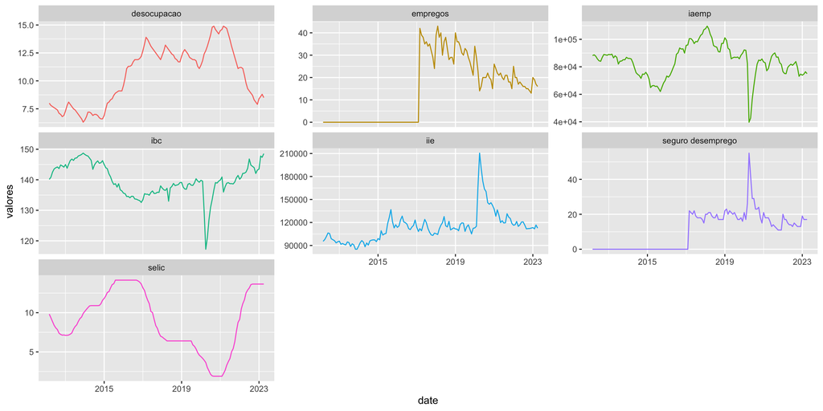

```r
# Converter os dados para o formato "long"
dados_long <-
  dados |>
       tidyr::pivot_longer(!date,
                           names_to = "variaveis",
                           values_to = "valores"
                           )

# Criar o gráfico
ggplot2::ggplot(dados_long) +
  ggplot2::geom_line(ggplot2::aes(x = date, y = valores, color = variaveis)) +
  ggplot2::facet_wrap(~variaveis, scales = "free_y") +
  ggplot2::scale_x_date(date_labels = "%Y", date_breaks = "4 years") +
  ggplot2::theme(legend.position = "none")
```

```r
# Teste de Cointegração de Johansen (teste automatizado que reporta o posto e lag)
rank_coint <- tsDyn::rank.select(
  data    = dados_ts,
  lag.max = 10,
  include = "const" # componentes determinísticos do VECM (constante)
)

rank_coint
```

```
Best AIC: rank= 7  lag= 10
Best BIC: rank= 0  lag= 1
Best HQ : rank= 2  lag= 1
```

```r
# Realiza o Teste usando a função ca.jo
summary(urca::ca.jo(dados_ts, type = 'eigen', K = 2, ecdet = 'const',
              spec = 'transitory'))
```

```
######################
# Johansen-Procedure #
######################

Test type: maximal eigenvalue statistic (lambda max) , without linear trend and constant in cointegration

Eigenvalues (lambda):
[1] 3.593871e-01 2.348633e-01 1.739097e-01 1.332766e-01 7.475782e-02
[6] 5.222046e-02 1.135796e-02 7.434751e-18

Values of teststatistic and critical values of test:

          test 10pct  5pct  1pct
r <= 6 |  1.51  7.52  9.24 12.97
r <= 5 |  7.08 13.75 15.67 20.20
r <= 4 | 10.26 19.77 22.00 26.81
r <= 3 | 18.88 25.56 28.14 33.24
r <= 2 | 25.22 31.66 34.40 39.79
r <= 1 | 35.34 37.45 40.30 46.82
r = 0  | 58.78 43.25 46.45 51.91

Eigenvectors, normalised to first column:
(These are the cointegration relations)

                     desocupacao.l1        ibc.l1      selic.l1   empregos.l1
desocupacao.l1         1.000000e+00  1.000000e+00  1.000000e+00  1.000000e+00
ibc.l1                -1.878553e+00  1.449436e-01  3.313565e-01  1.890412e+00
selic.l1               2.601304e-01  8.965209e-02  8.246111e-02  2.991500e+00
empregos.l1           -1.075064e+00 -8.712866e-02  3.124355e-02 -2.870897e+00
seguro.desemprego.l1   1.778180e+00  1.007401e-01 -4.115116e-01  2.735257e+00
iaemp.l1              -2.275936e-04 -6.647586e-05 -1.465715e-04  2.942282e-03
iie.l1                -8.462197e-04 -1.074166e-04  1.553973e-04  9.526450e-04
constant               3.621389e+02 -1.353022e+01 -5.923911e+01 -6.457234e+02
                     seguro.desemprego.l1      iaemp.l1        iie.l1
desocupacao.l1               1.000000e+00  1.000000e+00  1.000000e+00
ibc.l1                       6.318168e-01  4.783617e-01 -1.469943e+00
selic.l1                    -2.989107e-01  1.057703e+00 -1.335754e+00
empregos.l1                 -3.625162e-01  1.542796e-01  4.805345e-01
seguro.desemprego.l1         5.200070e-01  2.577966e-01 -1.043205e+00
iaemp.l1                    -3.432462e-05 -5.229392e-05 -5.778630e-05
```

[output cut: 24 more lines]

```
desocupacao.d                -0.00631347 -6.626346e-03 -0.0004139259
ibc.d                         0.06773312  2.222241e-02  0.0066078789
selic.d                       0.01435397 -4.378915e-03  0.0002456186
empregos.d                   -0.03210366 -8.122054e-02  0.0070508432
seguro.desemprego.d          -0.15609222 -6.419979e-02  0.0088420959
iaemp.d                      -8.30175375  3.252478e+01  3.3490079134
iie.d                      -212.84328389 -1.073074e+02 -4.9105603633
                         constant
desocupacao.d       -7.722042e-16
ibc.d               -5.869984e-15
selic.d              1.033969e-16
empregos.d           1.315212e-14
seguro.desemprego.d  1.937824e-14
iaemp.d             -2.987763e-11
iie.d               -4.291629e-11
```

```r
# Estimar VECM
fit_vecm <- tsDyn::VECM(
  data    = dados_ts,
  lag     = rank_coint$HQ_min[, "lag"],
  r       = rank_coint$HQ_min[, "rank"],
  include = "const",
  estim   = "ML",
  exogen = forecast::seasonaldummy(x = dados_ts[, "desocupacao"])
)

summary(fit_vecm)
```

```
#############
###Model VECM
#############
Full sample size: 134   End sample size: 132
Number of variables: 7  Number of estimated slope parameters 147
AIC 4300.936    BIC 4753.536    SSR 7167046075
Cointegrating vector (estimated by ML):
   desocupacao ibc       selic   empregos seguro desemprego         iaemp
r1           1   0  0.15199253 -0.2097503         0.3252409 -3.553857e-05
r2           0   1 -0.01124626  0.3929251        -0.6308319  1.545753e-04
             iie
r1 -0.0001750959
r2  0.0003338637

                           ECT1                   ECT2
Equation desocupacao       -0.0431(0.0122)***     -0.0209(0.0042)***
Equation ibc               0.0074(0.1813)         -0.2104(0.0630)**
Equation selic             -0.0224(0.0242)        -0.0002(0.0084)
Equation empregos          1.0800(0.4661)*        -0.0319(0.1620)
Equation seguro desemprego 0.1276(0.3583)         0.3737(0.1246)**
Equation iaemp             546.4981(364.6566)     -405.9431(126.7905)**
Equation iie               310.6058(732.3435)     153.1594(254.6347)
                           Intercept
Equation desocupacao       3.4894(0.7496)***
Equation ibc               40.2513(11.1640)***
Equation selic             -0.1679(1.4909)
Equation empregos          16.5253(28.6966)
Equation seguro desemprego -69.6565(22.0597)**
Equation iaemp             83851.5817(22453.3003)***
Equation iie               -25403.0418(45093.1876)
                           desocupacao -1            ibc -1
Equation desocupacao       0.5332(0.0676)***         -0.0099(0.0090)
Equation ibc               -0.7163(1.0065)           0.3882(0.1335)**
Equation selic             -0.1619(0.1344)           0.0055(0.0178)
Equation empregos          3.2843(2.5872)            0.4857(0.3432)
Equation seguro desemprego 2.2159(1.9888)            -0.6126(0.2638)*
Equation iaemp             1962.2871(2024.3281)      1124.7394(268.5401)***
Equation iie               -4784.1888(4065.4784)     -1356.8961(539.3118)*
                           selic -1                  empregos -1
Equation desocupacao       -0.0664(0.0304)*          -0.0022(0.0035)
```

[output cut: 47 more lines]

```
Equation desocupacao       0.0002(0.0531)           -0.1112(0.0524)*
Equation ibc               -0.4155(0.7909)          0.0136(0.7799)
Equation selic             -0.0549(0.1056)          -0.1135(0.1042)
Equation empregos          0.7303(2.0329)           0.8789(2.0046)
Equation seguro desemprego 0.0933(1.5628)           -0.7132(1.5410)
Equation iaemp             -898.1784(1590.6336)     1.4621(1568.5062)
Equation iie               -227.6257(3194.4855)     151.6437(3150.0468)
                           Oct                      Nov
Equation desocupacao       -0.0996(0.0519).         -0.0672(0.0520)
Equation ibc               0.5365(0.7733)           -0.9488(0.7743)
Equation selic             -0.0024(0.1033)          -0.0649(0.1034)
Equation empregos          1.3635(1.9879)           0.7106(1.9903)
Equation seguro desemprego -0.4163(1.5281)          0.4063(1.5300)
Equation iaemp             1166.8437(1555.3768)     -1371.5672(1557.2902)
Equation iie               -5597.5582(3123.6788).   -1481.5278(3127.5216)
```

```r
fit_tidy <- fit_vecm %>%
  summary() %>%
  purrr::pluck("Pvalues") %>%
  dplyr::as_tibble(rownames = ".response") %>%
  tidyr::pivot_longer(
    cols      = -".response",
    names_to  = "term",
    values_to = "p.value"
  ) %>%
  dplyr::mutate(.model = "vecm")

# Quantos coeficientes foram significativos por modelo?
fit_tidy %>%
  dplyr::group_by(.model) %>%
  dplyr::summarise(
    n_coeficientes      = dplyr::n(),
    n_significativos    = sum(p.value < 0.05),
    perc_significativos = n_significativos / n_coeficientes * 100
  )
```

| .model | n_coeficientes | n_significativos | perc_significativos |
| --- | --- | --- | --- |
| vecm | 147 | 32 | 21.76871 |

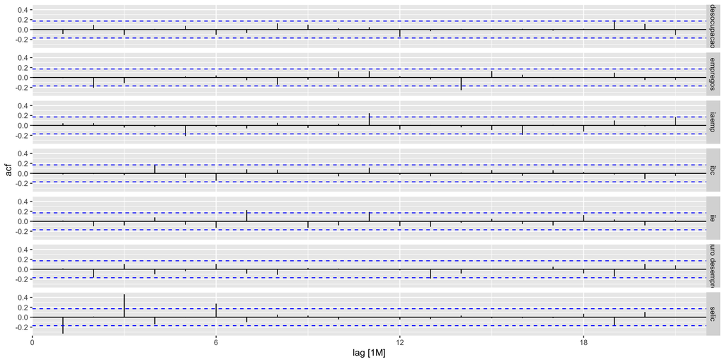

```r
resids_vecm <- fit_vecm %>%
  residuals() %>%
  dplyr::as_tibble() %>%
  dplyr::mutate(
    data = seq.Date(
      from       = min(dados$date),
      by         = "month",
      length.out = nrow(.)
    ) %>% tsibble::yearmonth()
  ) %>%
  tidyr::pivot_longer(
    cols      = -"data",
    names_to  = ".response",
    values_to = ".resid"
  ) %>%
  tsibble::as_tsibble(index = "data", key = ".response")

# ACF
resids_vecm %>%
  feasts::ACF(.resid) %>%
  fabletools::autoplot()
```

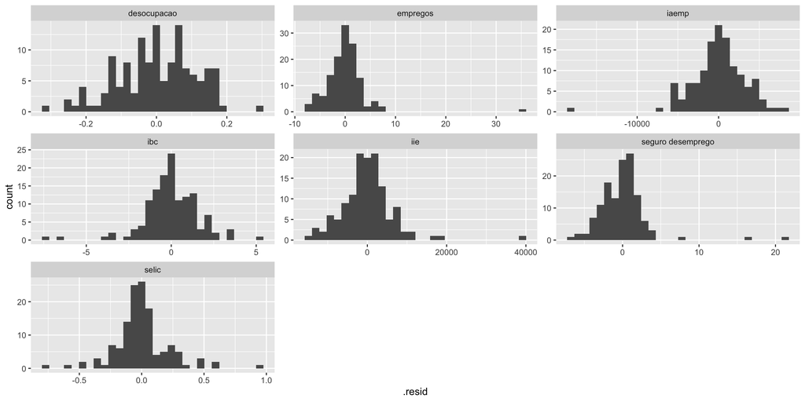

```r
# Histograma
resids_vecm %>%
  ggplot2::ggplot() +
  ggplot2::aes(x = .resid) +
  ggplot2::geom_histogram() +
  ggplot2::facet_wrap(~ .response, scales = "free")
```

```r
# Restringir dados (amostra de treino)
dados_treino <- dados %>%
  dplyr::slice(1:(dplyr::n() - 12))

dados_treino_mts <- stats::window(
  x     = dados_ts,
  start = stats::start(dados_ts),
  end   = c(
    lubridate::year(max(dados_treino$date)),
    lubridate::month(max(dados_treino$date))
  )
)

# Dados usados para comparar previsão (amostra de teste)
dados_teste <- dados %>%
  dplyr::filter(date > max(dados_treino$date))

dados_teste_mts <- stats::window(
  x     = dados_ts,
  start = c(
    lubridate::year(max(dados_treino$date)),
    lubridate::month(max(dados_treino$date)) + 1
  ),
  end   = stats::end(dados_ts)
)
```

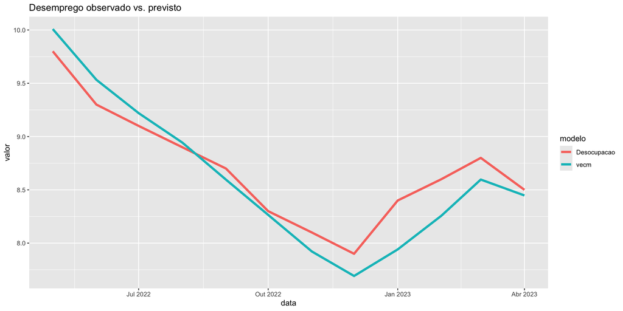

```r
# Reestimar modelos com restrição de amostra
rank_coint <- tsDyn::rank.select(
  data    = dados_treino_mts,
  lag.max = 5,
  include = "const"
)

fit_vecm_train <- tsDyn::VECM( # VECM
  data    = dados_treino_mts,
  lag     = rank_coint$HQ_min[, "lag"],
  r       = rank_coint$HQ_min[, "rank"],
  include = "const",
  estim   = "ML",
  exogen  = forecast::seasonaldummy(x = dados_treino_mts[, "desocupacao"])
)

# Previsões do VECM
fc_vecm_teste <- predict(
  fit_vecm_train,
  n.ahead = 12,
  exoPred = forecast::seasonaldummy(x = dados_treino_mts[, "desocupacao"], h = 12)
)

# Plotando as previsões vs. observado
fc_tbl_teste <- tibble::tibble(
  data  = lubridate::as_date(dados_teste$date),
  Desocupacao = dados_teste$desocupacao,
  vecm  = fc_vecm_teste[, "desocupacao"]
)

fc_tbl_teste %>%
  tidyr::pivot_longer(
    cols      = -"data",
    names_to  = "modelo",
    values_to = "valor"
  ) %>%
  ggplot2::ggplot() +
  ggplot2::aes(x = data, y = valor, color = modelo) +
  ggplot2::geom_line(size = 1.5) +
  ggplot2::labs(title = "Desemprego observado vs. previsto")
```

```r
# Métricas de acurácia
tsDyn::accuracy_stat(
  fc_vecm_teste,
  dados_teste_mts
)
```

```
                             ME         RMSE          MAE       MPE      MAPE
desocupacao        8.150755e-02    0.2186051    0.1823663  1.032638  2.106286
ibc                3.142117e+00    4.2036241    3.1778005  2.142145  2.167262
selic             -5.884785e-01    0.9008741    0.6896675 -4.287509  5.076198
empregos           6.096583e+00    6.4356425    6.0965827 37.778494 37.778494
seguro desemprego  1.687319e+00    2.6469115    2.1027094 10.665031 13.551108
iaemp              7.640003e+03 8488.4136210 7640.0025468  9.675761  9.675761
iie               -7.581552e+03 8967.3181771 7581.5522831 -6.671798  6.671798
global             9.838473e+00 4666.9970162 2176.2577081  7.190680 11.003844
```

```r
# Função para calcular U de Theil (versão 2: Theil, 1966)
u_theil <- function(actual, forecast) {

  n <- length(actual)
  test <- 1:n

  fpe <- (c(forecast[2:n]) / c(actual[1:(n - 1)]) - 1)[test - 1]
  ape <- (c(actual[2:n]) / c(actual[1:(n - 1)]) - 1)[test - 1]
  theil <- sqrt(sum((fpe - ape)^2, na.rm = TRUE) / sum(ape^2, na.rm = TRUE))

  return(theil)

}

u_theil(actual = fc_tbl_teste$Desocupacao, forecast = fc_tbl_teste$vecm)
```

```
[1] 0.7496841
```

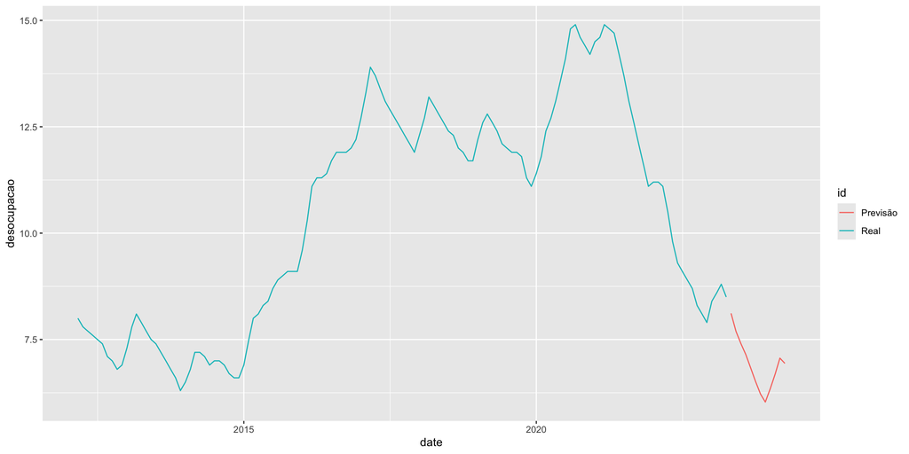

```r
# Previsões do VECM
fc_vecm <- predict(
  fit_vecm,
  n.ahead = 12,
  exoPred = forecast::seasonaldummy(x = dados_treino_mts[, "desocupacao"], h = 12)
)

fcst <- dados |>
  dplyr::select(date, desocupacao) |>
  dplyr::mutate("id" = "Real") |>
  dplyr::bind_rows(
         fc_vecm[, "desocupacao"] %>%
         dplyr::as_tibble() %>%
         dplyr::mutate(
            "date" = seq.Date(
              from = dplyr::last(dados$date) %m+% months(1),
              by = "month",
              length.out = nrow(.)
              ),
            "id" = "Previsão"
            ) |>
           dplyr::rename("desocupacao" = value)
    )

fcst |>
  ggplot2::ggplot()+
  ggplot2::aes(x = date, y = desocupacao, color = id)+
  ggplot2::geom_line()
```